# Analysis for WSN abstract

M Fisher

2022-10-11

# Description

Summarize the following from the sequencing run:

1. Prey diversity:
1. alpha diversity - what proportion of reads were identified down to genus or species?
2. beta diversity - What was the unique number of taxa identified per site/month? per site?
3. nMDS
2. Prey identification:
1. what proportion of crab from each site had eaten a given phylum / class?

For this script, I’m going to remove identifications that with too little taxonomic depth (information at family or below is missing), and IDs that may have made it through filtering (rank is specific but all other taxonomic info is missing)

```r
dat.filter <- dat %>%
  filter (rank %in% c("family","species","genus")) %>%
  filter (!(is.na(phylum) & is.na(class) & is.na(family) & is.na(order) & is.na(genus)))
```

And let’s check the number of crab / site with 1,2 and 3 replicates retained.

```
## # A tibble: 4 x 2
##   Site      `Crab count`
##   <chr>            <int>
## 1 CLAY                10
## 2 KAY                 11
## 3 KAY-shell            6
## 4 MARPT                2
```

```
##            nreps
## Site         2  3
##   CLAY       0 10
##   KAY        1 10
##   KAY-shell  1  5
##   MARPT      0  2
```

Good, most crab have all three replicates retained after filtering.

# Prey Diversity

### Alpha div

What is the species richness ($\alpha$ diversity) at each site, for **species?** Richness per crab is simply the species richness / total crab from site.

```
## # A tibble: 4 x 4
##   Site      ncrab richness richness.per.crab
##   <chr>     <int>    <int>             <dbl>
## 1 CLAY         10       50              5
## 2 KAY          11       40              3.64
## 3 KAY-shell     6       28              4.67
## 4 MARPT         2       11              5.5
```

What is the species richness ($\alpha$ diversity) at each site, for **genus?**

```
## # A tibble: 4 x 4
##   Site      ncrab richness richness.per.crab
##   <chr>     <int>    <int>             <dbl>
## 1 CLAY         10       56              5.6
## 2 KAY          11       46              4.18
## 3 KAY-shell     6       34              5.67
## 4 MARPT         2       14              7
```

### Beta div

What is the species richness ($\beta$ diversity) for species? (the ratio between regional and local species diversity) Note that for this sequencing run only, I include *Hemigrapsus sp* and *Mya sp* to species level.

```
##           1         2         3
## 2 0.4571429
## 3 0.7173913 0.7750000
## 4 0.8867925 0.9024390 0.7777778
```

```
## [1] "KAY"       "KAY-shell" "CLAY"      "MARPT"
```

The greater the similarity in community composition between multiple communities, the lower the value of β-diversity for that set of communities.

Beta diversity is greater between distant sites (Kayak Point v. Clayton Beach v. March Point) than it is between neighboring sites (Kayak Point eelgrass v. shell).

### nMDS

```
## *** Solution reached
```

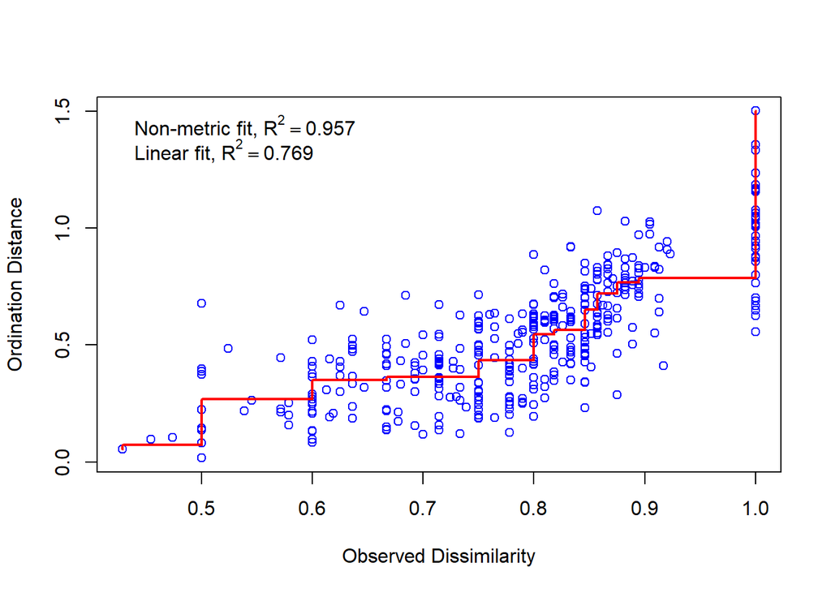

Disclaimer that **the stress is at 0.2, which is potentially misleading**.

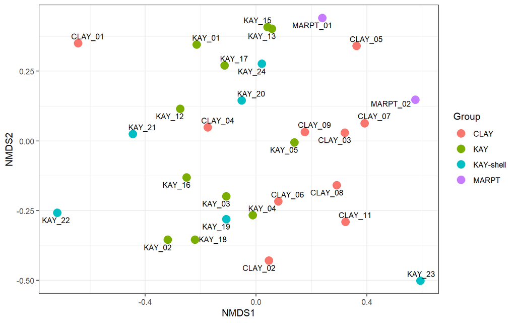

lol what a mess.

## Saturation

### Overall

How many unique taxa are added per new crab?

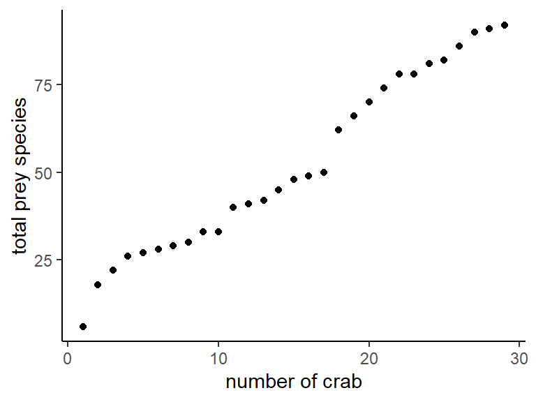

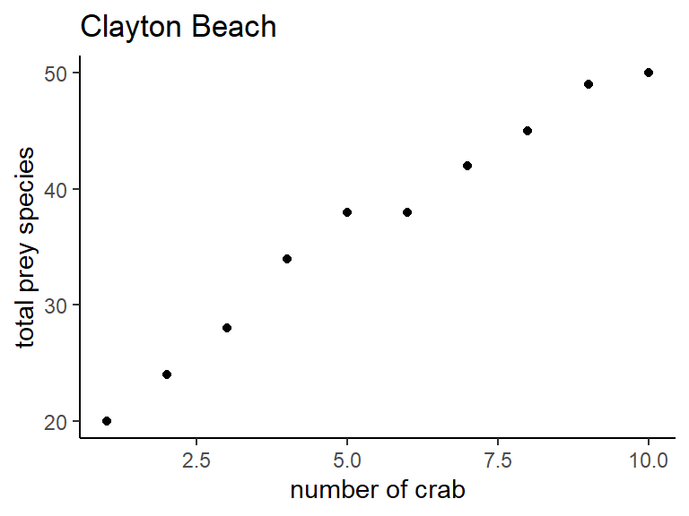

At higher taxonomic levels:

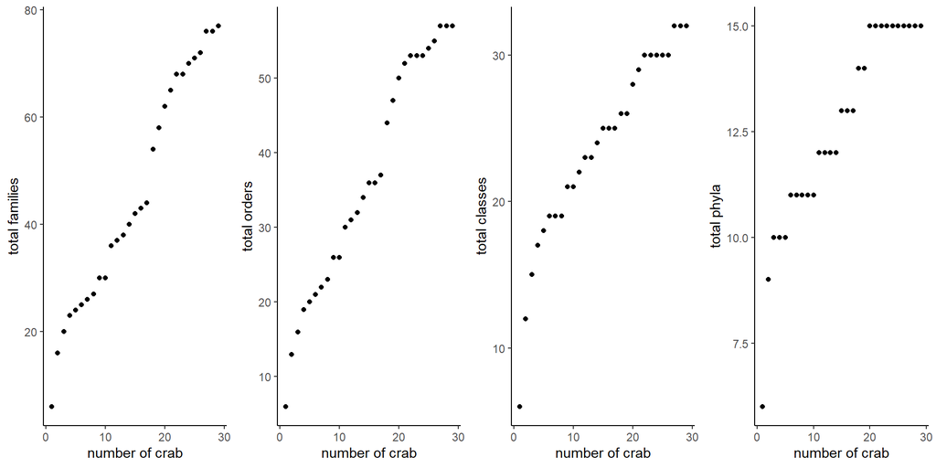

### By site

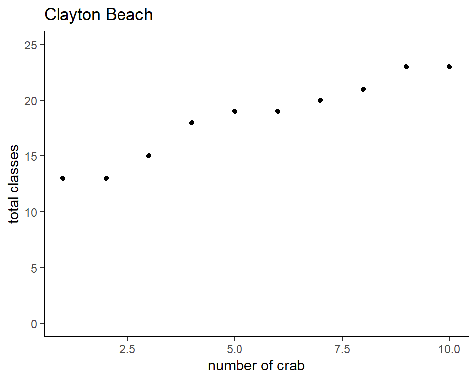

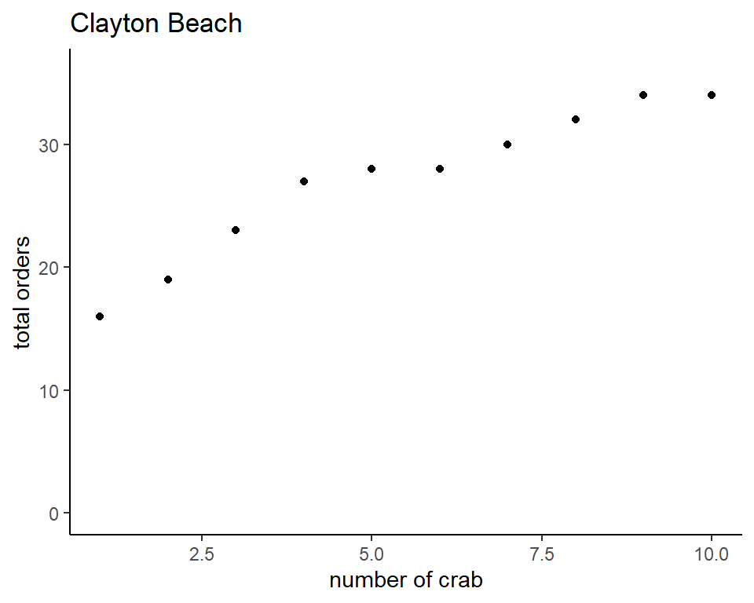

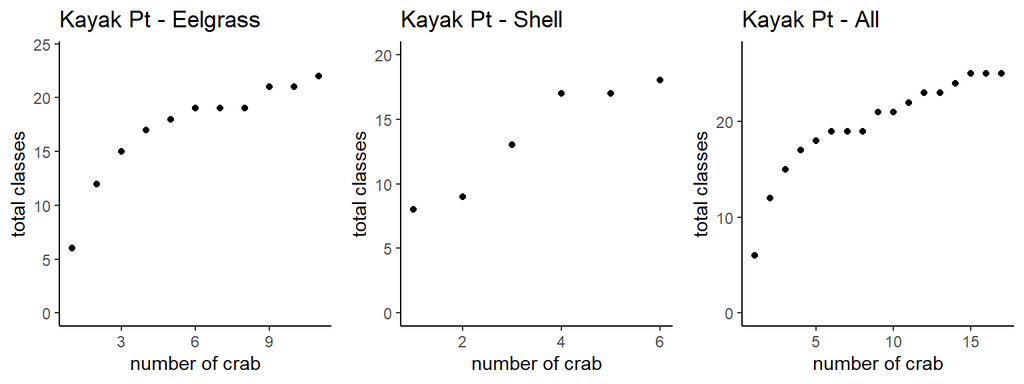

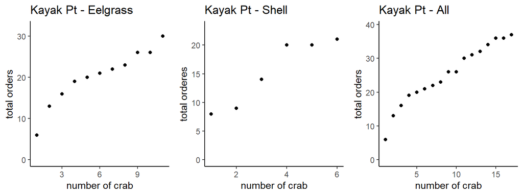

# Prey Identification

## Overall

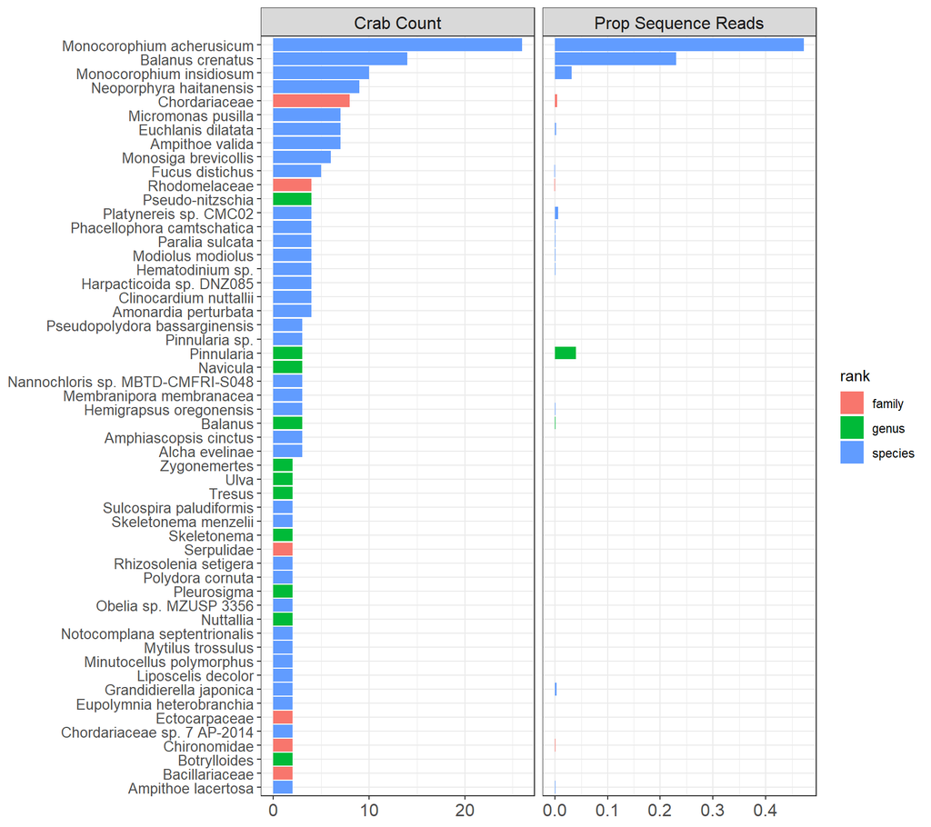

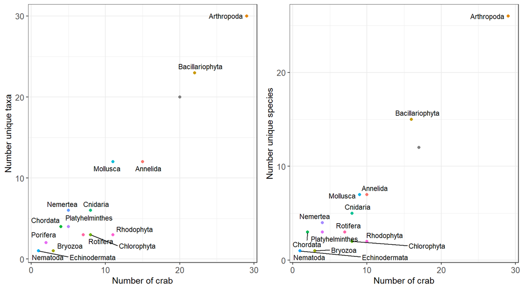

save this summary

```r
write_csv(taxa_summary,here(indir, 'lerayXT_r1_taxonomy_summary.csv'))
```

## By site

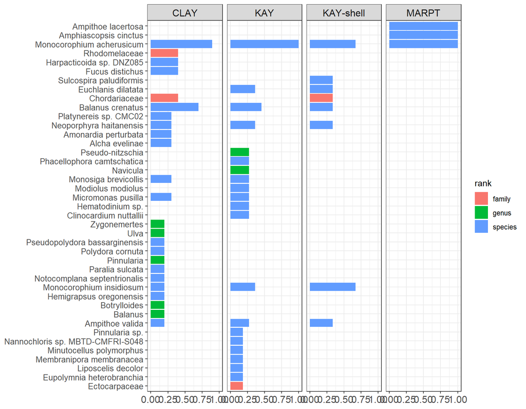

save this summary

```r
write_csv(taxa_summary_bysite,here(indir, 'lerayXT_r1_taxonomy_summary_by_site.csv'))
```

What about at higher orders of taxonomy? For only those identifications to species.

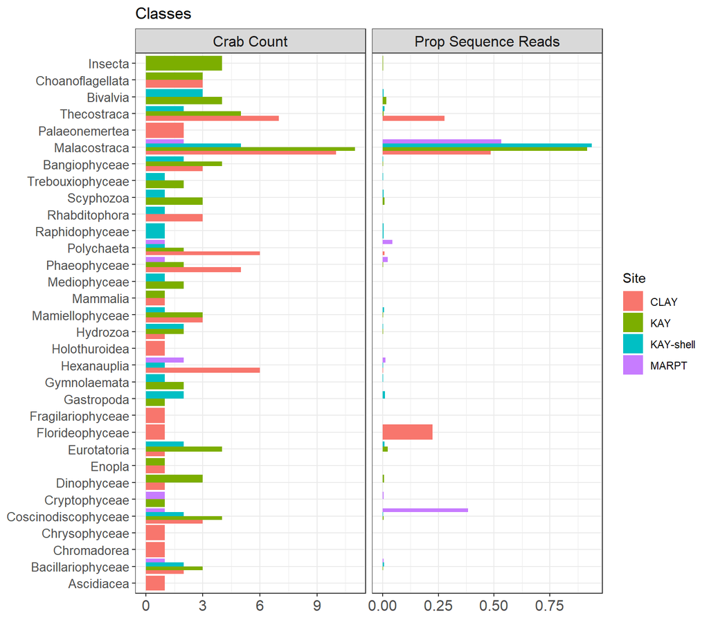

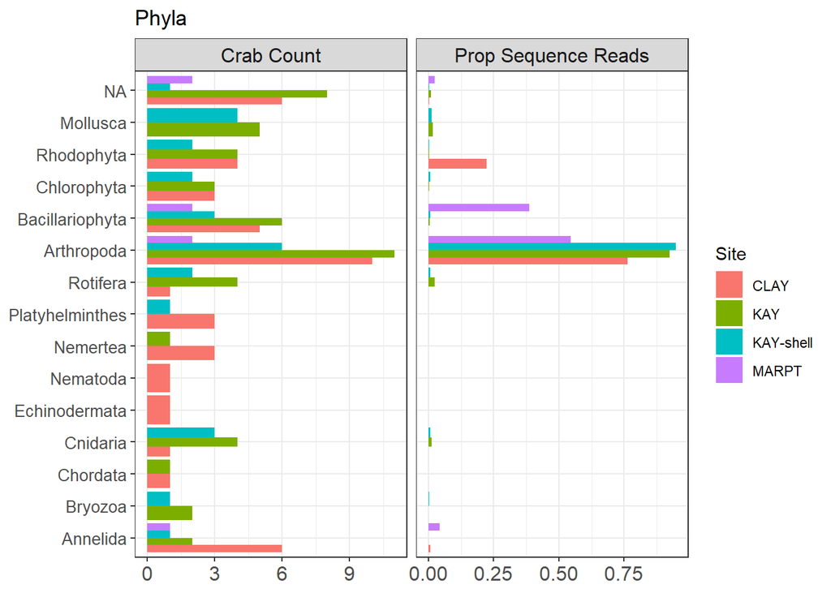

What’s going on with the “NA” phylum?

```
##  [1] "Chordariaceae sp. 7 AP-2014"    "Chordariaceae"
##  [3] "Petalonia fascia"               "Scytosiphon sp. Mitopromiscuus"
##  [5] "Scytosiphon"                    "Hematodinium sp."
##  [7] "Monosiga brevicollis"           "Ectocarpaceae"
##  [9] "Guillardia theta"               "Heterosigma akashiwo"
## [11] "Colpomenia sinuosa"             "Fucus distichus"
## [13] "Ectocarpus crouaniorum"         "Ralfsiaceae"
## [15] "Cryptomonas curvata"            "Hincksia"
## [17] "Paraphysomonas sp."             "Sargassum"
## [19] "Acinetosporaceae"               "Saccharina"
```

Some larger algae, some single-celled algae.